# ExtraaLearn Project

## Context

The EdTech industry has been surging in the past decade immensely, and according to a forecast, the Online Education market would be worth $286.62bn by 2023 with a compound annual growth rate (CAGR) of 10.26% from 2018 to 2023. The modern era of online education has enforced a lot in its growth and expansion beyond any limit. Due to having many dominant features like ease of information sharing, personalized learning experience, transparency of assessment, etc, it is now preferable to traditional education.

In the present scenario due to the Covid-19, the online education sector has witnessed rapid growth and is attracting a lot of new customers. Due to this rapid growth, many new companies have emerged in this industry. With the availability and ease of use of digital marketing resources, companies can reach out to a wider audience with their offerings. The customers who show interest in these offerings are termed as leads. There are various sources of obtaining leads for Edtech companies, like

- The customer interacts with the marketing front on social media or other online platforms.
- The customer browses the website/app and downloads the brochure
- The customer connects through emails for more information.

The company then nurtures these leads and tries to convert them to paid customers. For this, the representative from the organization connects with the lead on call or through email to share further details.

## Objective

ExtraaLearn is an initial stage startup that offers programs on cutting-edge technologies to students and professionals to help them upskill/reskill. With a large number of leads being generated on a regular basis, one of the issues faced by ExtraaLearn is to identify which of the leads are more likely to convert so that they can allocate resources accordingly. You, as a data scientist at ExtraaLearn, have been provided the leads data to:

- Analyze and build an ML model to help identify which leads are more likely to convert to paid customers,
- Find the factors driving the lead conversion process
- Create a profile of the leads which are likely to convert

## Data Description

The data contains the different attributes of leads and their interaction details with ExtraaLearn. The detailed data dictionary is given below.

**Data Dictionary**

- ID: ID of the lead
- age: Age of the lead
- current_occupation: Current occupation of the lead. Values include 'Professional','Unemployed',and 'Student'
- first_interaction: How did the lead first interacted with ExtraaLearn. Values include 'Website', 'Mobile App'
- profile_completed: What percentage of profile has been filled by the lead on the website/mobile app. Values include Low - (0-50%), Medium - (50-75%), High (75-100%)
- website_visits: How many times has a lead visited the website
- time_spent_on_website: Total time spent on the website
- page_views_per_visit: Average number of pages on the website viewed during the visits.
- last_activity: Last interaction between the lead and ExtraaLearn.
  - Email Activity: Seeking for details about program through email, Representative shared information with lead like brochure of program , etc
  - Phone Activity: Had a Phone Conversation with representative, Had conversation over SMS with representative, etc
  - Website Activity: Interacted on live chat with representative, Updated profile on website, etc
- print_media_type1: Flag indicating whether the lead had seen the ad of ExtraaLearn in the Newspaper.
- print_media_type2: Flag indicating whether the lead had seen the ad of ExtraaLearn in the Magazine.
- digital_media: Flag indicating whether the lead had seen the ad of ExtraaLearn on the digital platforms.
- educational_channels: Flag indicating whether the lead had heard about ExtraaLearn in the education channels like online forums, discussion threads, educational websites, etc.
- referral: Flag indicating whether the lead had heard about ExtraaLearn through reference.
- status: Flag indicating whether the lead was converted to a paid customer or not.

```python
from google.colab import drive
drive.mount('/content/drive')
```

## Importing necessary libraries and data

```python
#Importing useful libraries
import pandas as pd
import numpy as np
import matplotlib.pyplot as plt
import seaborn as sns

# To scale the data using z-score
from sklearn.preprocessing import StandardScaler

from sklearn.model_selection import train_test_split

# Algorithms to use
from sklearn.linear_model import LogisticRegression

from sklearn.svm import SVC

from sklearn.tree import DecisionTreeClassifier

from sklearn.ensemble import BaggingClassifier

from sklearn.ensemble import RandomForestClassifier

# Metrics to evaluate the model
from sklearn import metrics
from sklearn.metrics import confusion_matrix, classification_report, precision_recall_curve,recall_score
from sklearn import tree


# For tuning the model
from sklearn.model_selection import GridSearchCV

# To ignore warnings
import warnings
warnings.filterwarnings("ignore")
```

```python
#Loading the dataset into a dataframe
df = pd.read_csv('/content/drive/MyDrive/Data Science Coursework/Project 2/ExtraaLearn.csv')
```

## Data Overview

- Observations
- Sanity checks

```python
#get sunnary of data
df.head()
```

|  | ID | age | current_occupation | first_interaction | profile_completed | website_visits | time_spent_on_website | page_views_per_visit | last_activity | print_media_type1 | print_media_type2 | digital_media | educational_channels | referral | status |
| --- | --- | --- | --- | --- | --- | --- | --- | --- | --- | --- | --- | --- | --- | --- | --- |
| 0 | EXT001 | 57 | Unemployed | Website | High | 7 | 1639 | 1.861 | Website Activity | Yes | No | Yes | No | No | 1 |
| 1 | EXT002 | 56 | Professional | Mobile App | Medium | 2 | 83 | 0.320 | Website Activity | No | No | No | Yes | No | 0 |
| 2 | EXT003 | 52 | Professional | Website | Medium | 3 | 330 | 0.074 | Website Activity | No | No | Yes | No | No | 0 |
| 3 | EXT004 | 53 | Unemployed | Website | High | 4 | 464 | 2.057 | Website Activity | No | No | No | No | No | 1 |
| 4 | EXT005 | 23 | Student | Website | High | 4 | 600 | 16.914 | Email Activity | No | No | No | No | No | 0 |

- Mix of string and numerical values for each feature in the dataset (Independent variables)
- Status (which is our dependent variable) is represented as 0 or 1

```python
#overview of data info
df.info()
```

```
<class 'pandas.core.frame.DataFrame'>
RangeIndex: 4612 entries, 0 to 4611
Data columns (total 15 columns):
 #   Column                 Non-Null Count  Dtype
---  ------                 --------------  -----
 0   ID                     4612 non-null   object
 1   age                    4612 non-null   int64
 2   current_occupation     4612 non-null   object
 3   first_interaction      4612 non-null   object
 4   profile_completed      4612 non-null   object
 5   website_visits         4612 non-null   int64
 6   time_spent_on_website  4612 non-null   int64
 7   page_views_per_visit   4612 non-null   float64
 8   last_activity          4612 non-null   object
 9   print_media_type1      4612 non-null   object
 10  print_media_type2      4612 non-null   object
 11  digital_media          4612 non-null   object
 12  educational_channels   4612 non-null   object
 13  referral               4612 non-null   object
 14  status                 4612 non-null   int64
dtypes: float64(1), int64(4), object(10)
memory usage: 540.6+ KB
```

**Observations:**

- There are 4612 obsevations and 15 columns in our dataset.
- All columns have 4612 non-null values indicating that there are no missing values.
- 1 float data type column, 4 integer columns and the rest (10) are of type 'object' (text).

```python
df.nunique()
```

|  | 0 |
| --- | --- |
| ID | 4612 |
| age | 46 |
| current_occupation | 3 |
| first_interaction | 2 |
| profile_completed | 3 |
| website_visits | 27 |
| time_spent_on_website | 1623 |
| page_views_per_visit | 2414 |
| last_activity | 3 |
| print_media_type1 | 2 |
| print_media_type2 | 2 |
| digital_media | 2 |
| educational_channels | 2 |
| referral | 2 |
| status | 2 |

**dtype:** int64

**Observations:**

- Column 'ID' seems to vary for every observation as denoted by the 4612 number of unique values. This likely means it is a unique identifier and offers no analytic insight so it can be dropped from the table.

**Let's drop the 'ID' column and separate our dataset into numerical and categorical columns to allow for proper data preprocessing and analysis:**

```python
#drop columns not needed
df=df.drop(['ID'],axis=1)
```

```python
df.head()
```

|  | age | current_occupation | first_interaction | profile_completed | website_visits | time_spent_on_website | page_views_per_visit | last_activity | print_media_type1 | print_media_type2 | digital_media | educational_channels | referral | status |
| --- | --- | --- | --- | --- | --- | --- | --- | --- | --- | --- | --- | --- | --- | --- |
| 0 | 57 | Unemployed | Website | High | 7 | 1639 | 1.861 | Website Activity | Yes | No | Yes | No | No | 1 |
| 1 | 56 | Professional | Mobile App | Medium | 2 | 83 | 0.320 | Website Activity | No | No | No | Yes | No | 0 |
| 2 | 52 | Professional | Website | Medium | 3 | 330 | 0.074 | Website Activity | No | No | Yes | No | No | 0 |
| 3 | 53 | Unemployed | Website | High | 4 | 464 | 2.057 | Website Activity | No | No | No | No | No | 1 |
| 4 | 23 | Student | Website | High | 4 | 600 | 16.914 | Email Activity | No | No | No | No | No | 0 |

```python
#separating numerical columns from categorical columns
num_cols = ['age','website_visits','time_spent_on_website','page_views_per_visit','status']

cat_cols = ['current_occupation','first_interaction','profile_completed','last_activity','print_media_type1','print_media_type2',
            'digital_media','educational_channels','referral', 'status']
```

```python
df[num_cols].head()
```

|  | age | website_visits | time_spent_on_website | page_views_per_visit | status |
| --- | --- | --- | --- | --- | --- |
| 0 | 57 | 7 | 1639 | 1.861 | 1 |
| 1 | 56 | 2 | 83 | 0.320 | 0 |
| 2 | 52 | 3 | 330 | 0.074 | 0 |
| 3 | 53 | 4 | 464 | 2.057 | 1 |
| 4 | 23 | 4 | 600 | 16.914 | 0 |

```python
df[cat_cols].head()
```

|  | current_occupation | first_interaction | profile_completed | last_activity | print_media_type1 | print_media_type2 | digital_media | educational_channels | referral | status |
| --- | --- | --- | --- | --- | --- | --- | --- | --- | --- | --- |
| 0 | Unemployed | Website | High | Website Activity | Yes | No | Yes | No | No | 1 |
| 1 | Professional | Mobile App | Medium | Website Activity | No | No | No | Yes | No | 0 |
| 2 | Professional | Website | Medium | Website Activity | No | No | Yes | No | No | 0 |
| 3 | Unemployed | Website | High | Website Activity | No | No | No | No | No | 1 |
| 4 | Student | Website | High | Email Activity | No | No | No | No | No | 0 |

## Exploratory Data Analysis (EDA)

- EDA is an important part of any project involving data.
- It is important to investigate and understand the data better before building a model with it.
- A few questions have been mentioned below which will help you approach the analysis in the right manner and generate insights from the data.
- A thorough analysis of the data, in addition to the questions mentioned below, should be done.

**Questions**

1. Leads will have different expectations from the outcome of the course and the current occupation may play a key role in getting them to participate in the program. Find out how current occupation affects lead status.
2. The company's first impression on the customer must have an impact. Do the first channels of interaction have an impact on the lead status?
3. The company uses multiple modes to interact with prospects. Which way of interaction works best?
4. The company gets leads from various channels such as print media, digital media, referrals, etc. Which of these channels have the highest lead conversion rate?
5. People browsing the website or mobile application are generally required to create a profile by sharing their personal data before they can access additional information.Does having more details about a prospect increase the chances of conversion?

## Data Preprocessing

- Missing value treatment (if needed)
- Feature engineering (if needed)
- Outlier detection and treatment (if needed)
- Preparing data for modeling
- Any other preprocessing steps (if needed)

```python
#get statistical summary of numerical columns
df[num_cols].describe().T
```

|  | count | mean | std | min | 25% | 50% | 75% | max |
| --- | --- | --- | --- | --- | --- | --- | --- | --- |
| age | 4612.0 | 46.201214 | 13.161454 | 18.0 | 36.00000 | 51.000 | 57.00000 | 63.000 |
| website_visits | 4612.0 | 3.566782 | 2.829134 | 0.0 | 2.00000 | 3.000 | 5.00000 | 30.000 |
| time_spent_on_website | 4612.0 | 724.011275 | 743.828683 | 0.0 | 148.75000 | 376.000 | 1336.75000 | 2537.000 |
| page_views_per_visit | 4612.0 | 3.026126 | 1.968125 | 0.0 | 2.07775 | 2.792 | 3.75625 | 18.434 |
| status | 4612.0 | 0.298569 | 0.457680 | 0.0 | 0.00000 | 0.000 | 1.00000 | 1.000 |

**Initial Statistical Observations:**

- The mean age seems to be about 46 years, while the oldest observation is 63 years old. 50th percentile seems to be 51 years which might be indicative of the EdTech industry being more appealing to more grown people likely due to busier lives and ease.
- The mean website visit is about 3 to 4 times but the max is 30 times which indicates a likely outlier.
- Columns website_visits, time_spent_on_website and page_view_per_visit seem to have maximum values that seem to deviate significantly from their means thereby indicating outliers of the maximum values.
- Leads seems to be converted to paid customers on an average of 30% based on this dataset.

Checking the distribution of the numerical columns with plots:

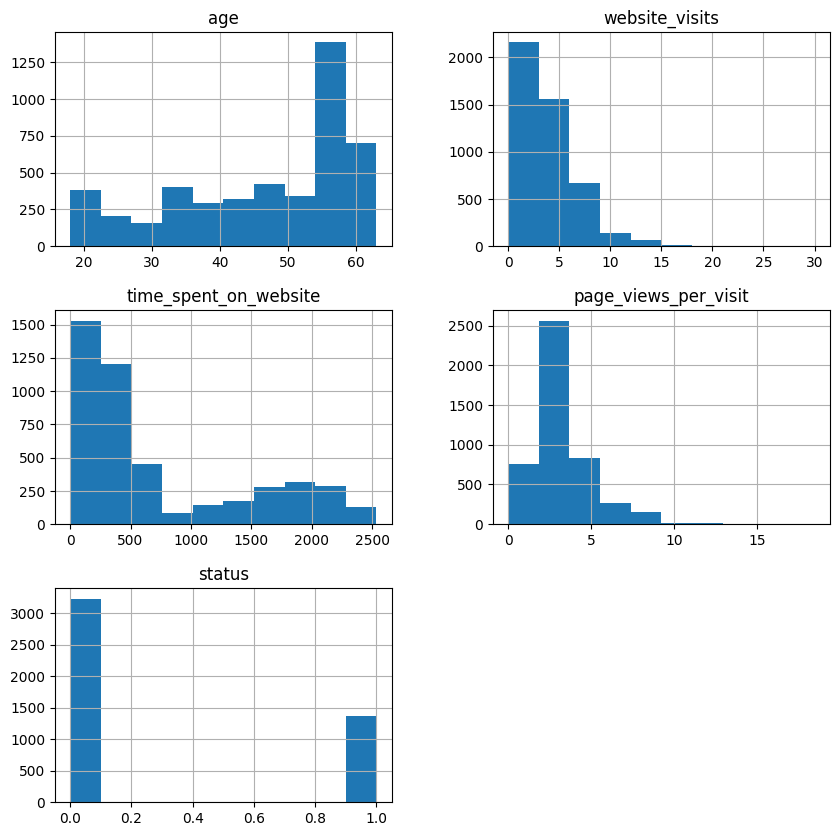

```python
# Creating histograms
df[num_cols].hist(figsize=(10,10))
plt.show()
```

**Observation:**

- Age seems to skewed left emphasizing the idea of older people being leads in the EdTech industry.
- The rest of the numerical columns seem to skew right showing less general interactions on the website.

```python
#observing frequencies in categorical columns
for i in cat_cols:
    print(df[i].value_counts(normalize=True))
    print('*'*30)
```

```
current_occupation
Professional    0.567216
Unemployed      0.312446
Student         0.120338
Name: proportion, dtype: float64
first_interaction
Website       0.551171
Mobile App    0.448829
Name: proportion, dtype: float64
profile_completed
High      0.490893
Medium    0.485906
Low       0.023200
Name: proportion, dtype: float64
last_activity
Email Activity      0.493929
Phone Activity      0.267563
Website Activity    0.238508
Name: proportion, dtype: float64
print_media_type1
No     0.892238
Yes    0.107762
Name: proportion, dtype: float64
print_media_type2
No     0.94948
Yes    0.05052
Name: proportion, dtype: float64
digital_media
No     0.885733
Yes    0.114267
Name: proportion, dtype: float64
educational_channels
No     0.847138
Yes    0.152862
Name: proportion, dtype: float64
referral
No     0.979835
Yes    0.020165
Name: proportion, dtype: float64
status
0    0.701431
1    0.298569
Name: proportion, dtype: float64
```

**Observations:**

## EDA

- It is a good idea to explore the data once again after manipulating it.

Bivariate and Multivariate Analysis

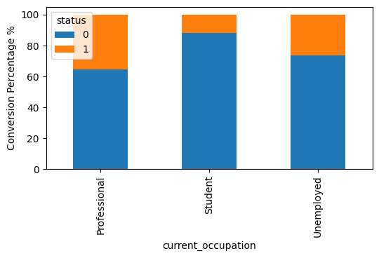

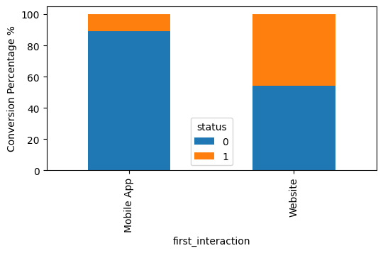

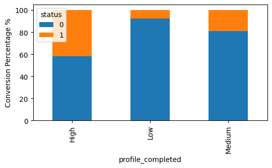

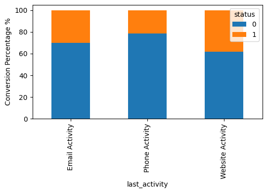

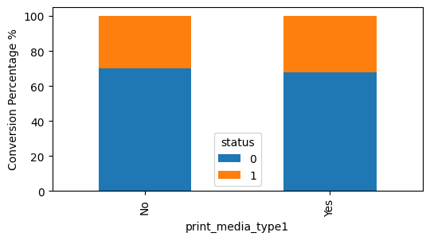

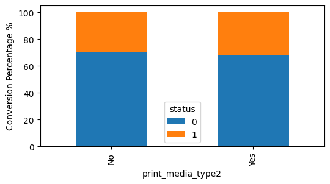

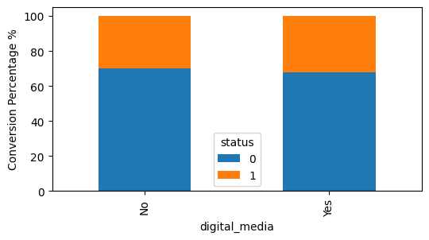

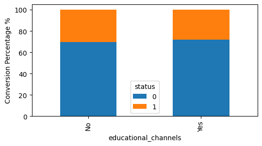

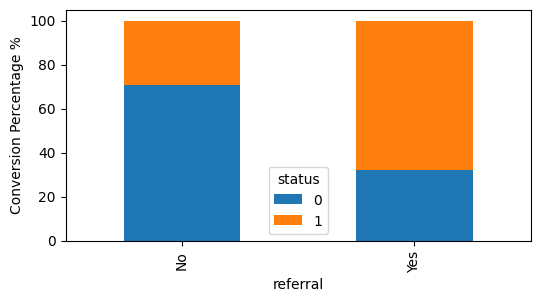

```python
#relationship of conversion status to our categorical independent features
for i in cat_cols:
    if i!='status':
        (pd.crosstab(df[i],df['status'],normalize='index')*100).plot(kind='bar',figsize=(6,3),stacked=True)
        plt.ylabel('Conversion Percentage %')
```

**Observations:**

- The percentage of conversion for professional and unemployed occupations is a lot higher than that of students.
- Website as a first interaction for leads has a significantly high conversion percentage.
- High profile completion seesm to be a pretty great indication of leads that could be converted as seen from the analysis of the profile completed plot.
- Website activity has a slightly higher conversion percentage than Email Activitiy which in turn is slightly higher than Phone Activity.
- None of the various channels of ads seems to have a significant conversion summary except referrals which has a very significant conversion (more than 60% conversion percentage) for people who answer 'Yes'.

```python
#numerical columns relationship with dependent variable
df.groupby(['status'])[num_cols].mean()
```

| status | age | website_visits | time_spent_on_website | page_views_per_visit | status |
| --- | --- | --- | --- | --- | --- |
| 0 | 45.153014 | 3.578980 | 577.420711 | 3.025732 | 0.0 |
| 1 | 48.663762 | 3.538126 | 1068.397967 | 3.027050 | 1.0 |

**Observation:**

- The mean for conversion or not seem pretty even for all the numerical columns except time spent on website which seems to have significantly larger mean for conversion. This likely indicates that leads who have spent more time on the website are likely to be converted into customers.

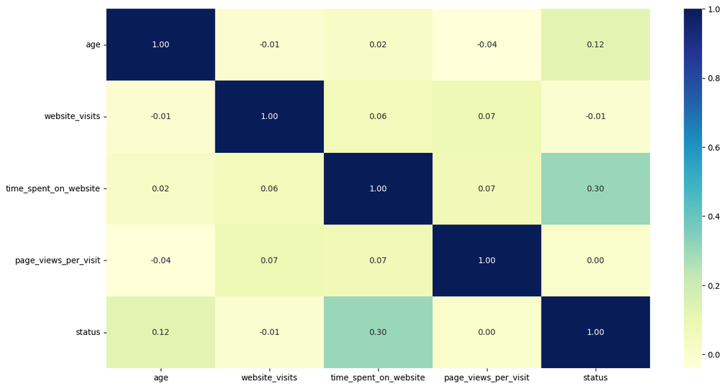

```python
# Plotting the correlation between numerical variables
plt.figure(figsize=(15,8))
sns.heatmap(df[num_cols].corr(),annot=True, fmt='0.2f', cmap='YlGnBu')
```

- Time spent on website seems to have the most correlation to leads conversion status.

## Building a Decision Tree model

```python
df.head()
```

|  | age | current_occupation | first_interaction | profile_completed | website_visits | time_spent_on_website | page_views_per_visit | last_activity | print_media_type1 | print_media_type2 | digital_media | educational_channels | referral | status |
| --- | --- | --- | --- | --- | --- | --- | --- | --- | --- | --- | --- | --- | --- | --- |
| 0 | 57 | Unemployed | Website | High | 7 | 1639 | 1.861 | Website Activity | Yes | No | Yes | No | No | 1 |
| 1 | 56 | Professional | Mobile App | Medium | 2 | 83 | 0.320 | Website Activity | No | No | No | Yes | No | 0 |
| 2 | 52 | Professional | Website | Medium | 3 | 330 | 0.074 | Website Activity | No | No | Yes | No | No | 0 |
| 3 | 53 | Unemployed | Website | High | 4 | 464 | 2.057 | Website Activity | No | No | No | No | No | 1 |
| 4 | 23 | Student | Website | High | 4 | 600 | 16.914 | Email Activity | No | No | No | No | No | 0 |

Prepare Data:

```python
#create dummies for categorical variables
dummies_for = ['current_occupation','first_interaction','profile_completed','last_activity']

df= pd.get_dummies(data = df, columns = dummies_for, drop_first = True)

dict_print_media_type1 = {'Yes': 1, 'No':0}
dict_print_media_type2 = {'Yes': 1, 'No':0}
dict_digital_media = {'Yes': 1, 'No':0}
dict_educational_channels = {'Yes': 1, 'No':0}
dict_referral = {'Yes': 1, 'No':0}

df['print_media_type1'] = df.print_media_type1.map(dict_print_media_type1)
df['print_media_type2'] = df.print_media_type2.map(dict_print_media_type2)
df['digital_media'] = df.digital_media.map(dict_digital_media)
df['educational_channels'] = df.educational_channels.map(dict_educational_channels)
df['referral'] = df.referral.map(dict_referral)
```

```python
df.head()
```

|  | age | website_visits | time_spent_on_website | page_views_per_visit | print_media_type1 | print_media_type2 | digital_media | educational_channels | referral | status | current_occupation_Student | current_occupation_Unemployed | first_interaction_Website | profile_completed_Low | profile_completed_Medium | last_activity_Phone Activity | last_activity_Website Activity |
| --- | --- | --- | --- | --- | --- | --- | --- | --- | --- | --- | --- | --- | --- | --- | --- | --- | --- |
| 0 | 57 | 7 | 1639 | 1.861 | 1 | 0 | 1 | 0 | 0 | 1 | False | True | True | False | False | False | True |
| 1 | 56 | 2 | 83 | 0.320 | 0 | 0 | 0 | 1 | 0 | 0 | False | False | False | False | True | False | True |
| 2 | 52 | 3 | 330 | 0.074 | 0 | 0 | 1 | 0 | 0 | 0 | False | False | True | False | True | False | True |
| 3 | 53 | 4 | 464 | 2.057 | 0 | 0 | 0 | 0 | 0 | 1 | False | True | True | False | False | False | True |
| 4 | 23 | 4 | 600 | 16.914 | 0 | 0 | 0 | 0 | 0 | 0 | True | False | True | False | False | False | False |

```python
#separate dependent and independent columns
Y= df.status
X= df.drop(columns = ['status'])
```

Splitting dataset into a 70-30% training/test dataset:

```python
# Splitting the data
X_train, X_test, y_train, y_test = train_test_split(X, Y, test_size = 0.3, random_state = 1, stratify = Y)
```

creating metric function:

```python
# Creating metric function
def metrics_score(actual, predicted):
    print(classification_report(actual, predicted))

    cm = confusion_matrix(actual, predicted)
    plt.figure(figsize=(8,5))

    sns.heatmap(cm, annot=True,  fmt='.2f', xticklabels=['Not Convert', 'Convert'], yticklabels=['Not Convert', 'Convert'])
    plt.ylabel('Actual')
    plt.xlabel('Predicted')
    plt.show()
```

```python
#building decision tree model
dt = DecisionTreeClassifier(class_weight = {0: 0.30, 1: 0.70}, random_state = 1)
```

```python
# Fitting decision tree model
dt.fit(X_train, y_train)
```

```
DecisionTreeClassifier(class_weight={0: 0.3, 1: 0.7}, random_state=1)
```

Checking decision tree model performance:

```
              precision    recall  f1-score   support

           0       1.00      1.00      1.00      2264
           1       1.00      1.00      1.00       964

    accuracy                           1.00      3228
   macro avg       1.00      1.00      1.00      3228
weighted avg       1.00      1.00      1.00      3228
```

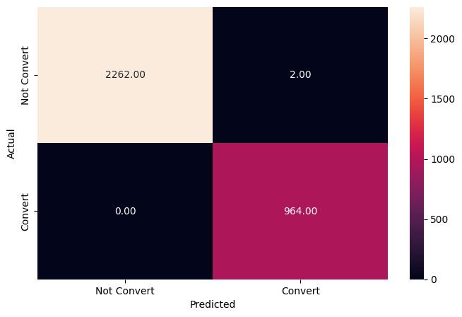

```python
# Checking performance on the training dataset
y_train_pred_dt = dt.predict(X_train)

#call defined metrics function
metrics_score(y_train, y_train_pred_dt)
```

**Observation:**

- Getting a 100% score on all metrics (recall and precision especially)

```
              precision    recall  f1-score   support

           0       0.84      0.86      0.85       971
           1       0.65      0.62      0.64       413

    accuracy                           0.79      1384
   macro avg       0.75      0.74      0.74      1384
weighted avg       0.79      0.79      0.79      1384
```

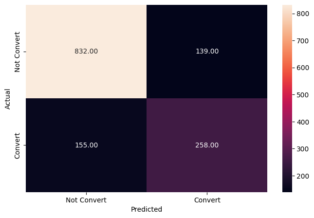

```python
# Checking performance on the test dataset
y_test_pred_dt = dt.predict(X_test)

#call metrics function
metrics_score(y_test, y_test_pred_dt)
```

**Observations:**

- There seems to be a heavy drop off in recall accuracy (62%) for the test data set which probably signifies that the model is overfitted onto the training dataset.
- The precision metrics value suggests that there is a 35% chance that the model will predict a lead to convert into a paying customer when in actuality they won't which could cost the business time, effort and money in trying to convert leads who would not end up converting into payiong customers.

**Attempting to check the most important features in assesing conversion:**

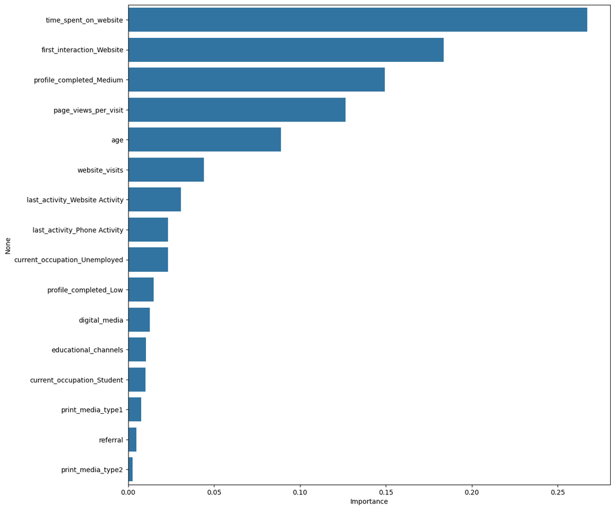

```python
# Plot the feature importance

importances = dt.feature_importances_
columns = X.columns
importance_df = pd.DataFrame(importances, index = columns, columns = ['Importance']).sort_values(by = 'Importance', ascending = False)
plt.figure(figsize = (13, 13))
sns.barplot(data = importance_df, x = importance_df.Importance, y = importance_df.index)
```

**Observations:**

- Time spent on website seems to by far be the most important feature in determining if a lead will convert into a paying customer.
- First interaction on website, profile completed medium and page views per visit are also really important features.
- A good conclusion from this will probably be for the ExtraaLearn to emphasize and propagate its online and website presence all around.

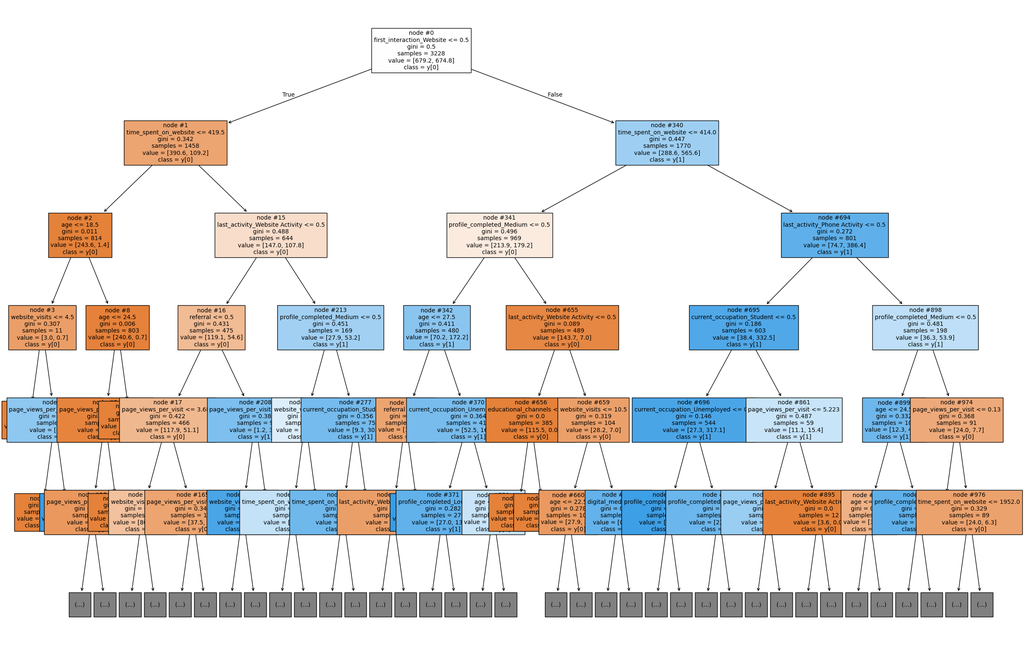

```python
#plotting the decision tree to a depth of 5
features = list(X.columns)
plt.figure(figsize = (30, 20))
tree.plot_tree(dt, max_depth = 5, feature_names = features, filled = True, fontsize = 10, node_ids = True, class_names = True)
plt.show()
```

## Do we need to prune the tree?

Considering the decision tree heavily overfitted onto the training dataset, then pruning will definitely be an adviseable means to allow for more variance within each node.

```python
#building decision tree model
dt_prune = DecisionTreeClassifier(max_depth = 10, class_weight = {0: 0.30, 1: 0.70}, random_state = 1)
```

```python
# Fitting decision tree model
dt_prune.fit(X_train, y_train)
```

```
DecisionTreeClassifier(class_weight={0: 0.3, 1: 0.7}, max_depth=10,
                       random_state=1)
```

Checking pruned decision tree performance

```
              precision    recall  f1-score   support

           0       0.97      0.91      0.94      2264
           1       0.82      0.94      0.88       964

    accuracy                           0.92      3228
   macro avg       0.90      0.92      0.91      3228
weighted avg       0.93      0.92      0.92      3228
```

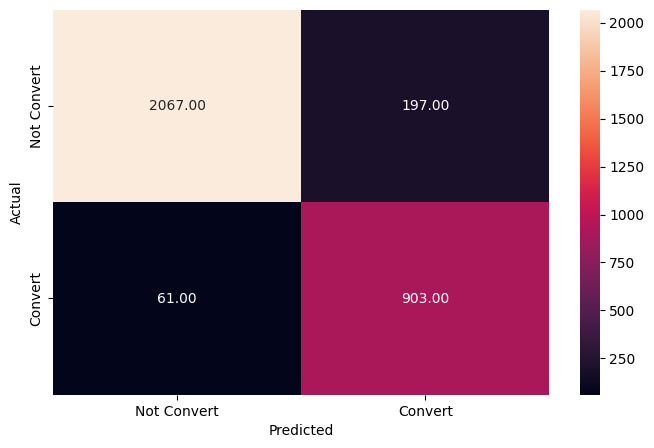

```python
# Checking performance on the training dataset
y_train_pred_dt_prune = dt_prune.predict(X_train)

#call defined metrics function
metrics_score(y_train, y_train_pred_dt_prune)
```

**Observations:**

```
              precision    recall  f1-score   support

           0       0.89      0.85      0.87       971
           1       0.68      0.76      0.72       413

    accuracy                           0.82      1384
   macro avg       0.79      0.81      0.80      1384
weighted avg       0.83      0.82      0.83      1384
```

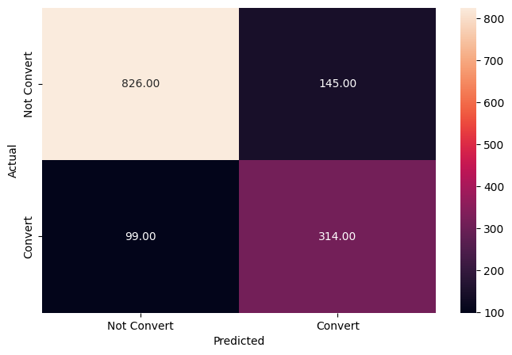

```python
# Checking performance on the test dataset
y_test_pred_dt_prune = dt_prune.predict(X_test)

#call metrics function
metrics_score(y_test, y_test_pred_dt_prune)
```

**Observations:**

- At a depth of 10, the decision tree model performs slightly better on the test data but it is still not anything too significant.

## Building a Random Forest model

```python
# Fitting the Random Forest classifier on the training data
rf = RandomForestClassifier(class_weight = {0: 0.30, 1: 0.70}, random_state = 1)

rf.fit(X_train, y_train)
```

```
RandomForestClassifier(class_weight={0: 0.3, 1: 0.7}, random_state=1)
```

```
              precision    recall  f1-score   support

           0       1.00      1.00      1.00      2264
           1       1.00      1.00      1.00       964

    accuracy                           1.00      3228
   macro avg       1.00      1.00      1.00      3228
weighted avg       1.00      1.00      1.00      3228
```

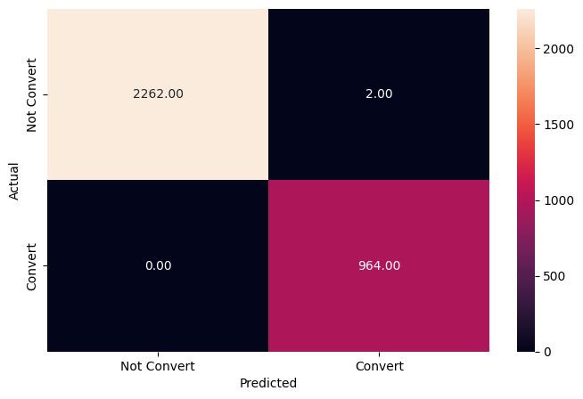

```python
# Checking performance on the training data
y_pred_train_rf = rf.predict(X_train)

metrics_score(y_train, y_pred_train_rf)
```

**Observation**:

- A 100% was achieved for every metric.

```
              precision    recall  f1-score   support

           0       0.88      0.91      0.90       971
           1       0.78      0.71      0.74       413

    accuracy                           0.85      1384
   macro avg       0.83      0.81      0.82      1384
weighted avg       0.85      0.85      0.85      1384
```

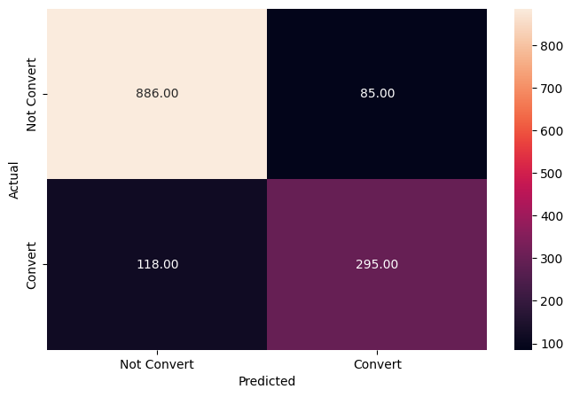

```python
# Checking performance on the testing data
y_pred_test_rf = rf.predict(X_test)

metrics_score(y_test, y_pred_test_rf)
```

**Observations:**

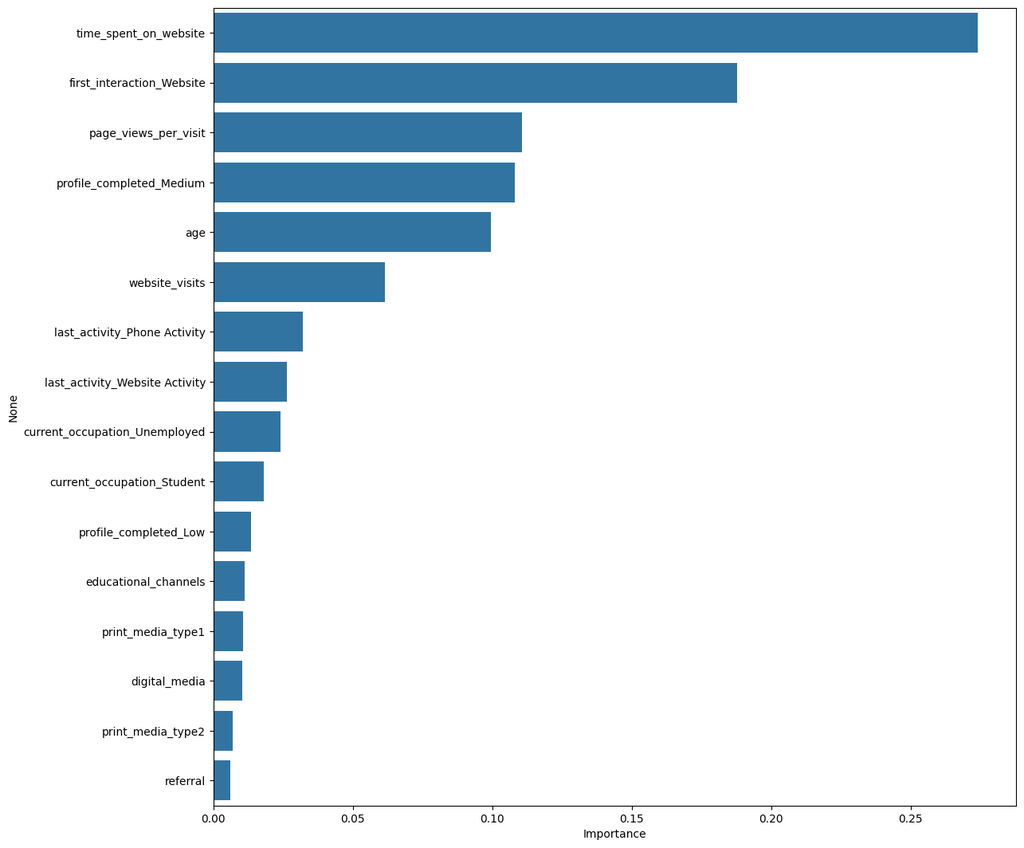

```python
importances = rf.feature_importances_
columns = X.columns
importance_df = pd.DataFrame(importances, index = columns, columns = ['Importance']).sort_values(by = 'Importance', ascending = False)
plt.figure(figsize = (13, 13))
sns.barplot(data = importance_df, x = importance_df.Importance, y = importance_df.index)
```

**Observations:**

- The general consensus of time spent on website, first interaction being on the website, page view per visit and profile completed at a medium level being the four most important features for conversion matches up pretty well with what was gotten from the decision tree.

## Do we need to prune the tree?

- Pruning is generally not needed for Random Forests as it uses bootstrapping to make the results more accurate.

## Actionable Insights and Recommendations

Recommendations and Insights:

- Time spent on website being the consensus most important feature for conversion means the website being appealing and engaging could offer the best route to converting a lot of leads into paying cutomers.
- A lot of the other top three important features also pertaining to the website (first interaction being on the website, page view per visit and profile completed at a medium level) means drawing eyes and bringing attention to the website in the first place should be paramount.
- There should be less of an emphasis on trying to convert students and a younger demographic as seen with the slight importance in age how left-skewed age is from the dataset.